# Problem 1: Traversal Algorithms (BFS vs. DFS)

A delivery robot must navigate a warehouse modeled as a graph where nodes represent storage areas and edges represent walkable paths. You must determine the best way for the robot to explore the entire warehouse efficiently.

```
A -- B -- C
|    |    |
D -- E -- F
|    |    |
G -- H -- I
```

## Code

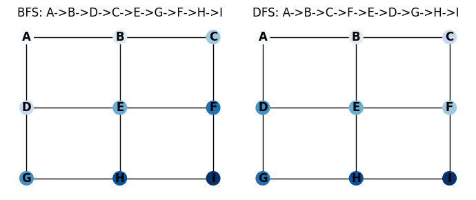

```python
from collections import deque
import matplotlib.pyplot as plt
import networkx as nx

# Define the warehouse as a graph (Adjacency List)
warehouse_graph = {
    'A': ['B', 'D'],
    'B': ['A', 'C', 'E'],
    'C': ['B', 'F'],
    'D': ['A', 'E', 'G'],
    'E': ['B', 'D', 'F', 'H'],
    'F': ['C', 'E', 'I'],
    'G': ['D', 'H'],
    'H': ['E', 'G', 'I'],
    'I': ['F', 'H']
}

pos = {
    'A': (0, 2), 'B': (1, 2), 'C': (2, 2),
    'D': (0, 1), 'E': (1, 1), 'F': (2, 1),
    'G': (0, 0), 'H': (1, 0), 'I': (2, 0)
}

def bfs(graph, start):
    visited = {k: False for k in graph}
    order = []
    visited[start] = True
    q = deque()
    q.append(start)
    while len(q) > 0:
        v = q.popleft()
        order.append(v)
        neighbors = [n for n in graph[v] if not visited[n]]
        for neighbor in neighbors:
            visited[neighbor] = True
            q.append(neighbor)
    return order

def dfs(graph, start, visited=None, order=None):
    if visited is None:
        visited = {k: False for k in graph}
        order = []

    visited[start] = True
    order.append(start)

    for neighbor in graph[start]:
        if not visited[neighbor]:
            dfs(graph, neighbor, visited, order)

    return order

# Run BFS and DFS
bfs_order = bfs(warehouse_graph, 'A')
dfs_order = dfs(warehouse_graph, 'A')

# Visualize side by side
G = nx.Graph(warehouse_graph)
fig, (ax1, ax2) = plt.subplots(1, 2, figsize=(7, 3))

bfs_colors = [bfs_order.index(node) for node in G.nodes()]
nx.draw(G, pos, ax=ax1, with_labels=True, node_color=bfs_colors, cmap=plt.cm.Blues,
        node_size=200, font_size=12, font_weight='bold')
ax1.set_title('BFS: ' + '->'.join(bfs_order))

dfs_colors = [dfs_order.index(node) for node in G.nodes()]
nx.draw(G, pos, ax=ax2, with_labels=True, node_color=dfs_colors, cmap=plt.cm.Blues,
        node_size=200, font_size=12, font_weight='bold')
ax2.set_title('DFS: ' + '->'.join(dfs_order))

plt.tight_layout()
plt.show()
```

## Response

The BFS and DFS traversls are shown above, with the traversal orders written, and reflected by how dark each node is (darker means later in the traversal order).

If the warehouse had multiple exits, BFS would be best at finding the shortest one quickest, because you are guarenteed that the first exit found is the shortest. With DFS, you would have to find all exits and then compare their path lengths.

# Problem 2: Decision Trees - Making Predictions from Data

A company wants to predict whether a customer will buy a product based on two features: Age Group (Young, Middle, Senior) and Income Level (Low, Medium, High). They plan to use a Decision Tree to classify potential customers.

You are given the following customer data

| Person | Age Group | Income | Buys Product? |
| --- | --- | --- | --- |
| 1 | Young | Low | No |
| 2 | Young | Medium | No |
| 3 | Young | High | Yes |
| 4 | Middle | Low | Yes |
| 5 | Middle | Medium | Yes |
| 6 | Middle | High | No |
| 7 | Senior | Low | Yes |
| 8 | Senior | Medium | Yes |
| 9 | Senior | High | No |

## Code

You may use `sklearn` to design your decision tree classifier. Your criterion for split should be what we discussed in the lecture.

```
Feature importances: {'Age': np.float64(0.07343556032986287), 'Income': np.float64(0.9265644396701371)}
```

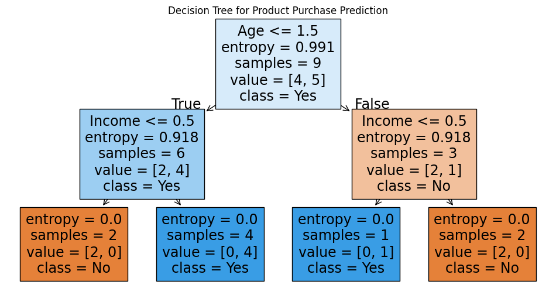

```
Prediction for Middle-aged, High income: No
```

```python
import pandas as pd
from sklearn.tree import DecisionTreeClassifier, export_text, plot_tree
from sklearn.preprocessing import LabelEncoder
import matplotlib.pyplot as plt

import warnings
warnings.filterwarnings('ignore', category=UserWarning, module='sklearn')

# Create the dataset
data = {
    'Age': ['Young', 'Young', 'Young', 'Middle', 'Middle', 'Middle', 'Senior', 'Senior', 'Senior'],
    'Income': ['Low', 'Medium', 'High', 'Low', 'Medium', 'High', 'Low', 'Medium', 'High'],
    'Buys': ['No', 'No', 'Yes', 'Yes', 'Yes', 'No', 'Yes', 'Yes', 'No']
}
df = pd.DataFrame(data)

# Encode categorical variables
le_age = LabelEncoder()
le_income = LabelEncoder()
le_buys = LabelEncoder()

df['Age_enc'] = le_age.fit_transform(df['Age'])
df['Income_enc'] = le_income.fit_transform(df['Income'])
df['Buys_enc'] = le_buys.fit_transform(df['Buys'])

X = df[['Age_enc', 'Income_enc']]
y = df['Buys_enc']

# Train decision tree with entropy criterion (information gain)
clf = DecisionTreeClassifier(criterion='entropy', random_state=42)
clf.fit(X, y)

# Analyze the tree
print('Feature importances:', dict(zip(['Age', 'Income'], clf.feature_importances_)))

# Visualize
plt.figure(figsize=(12, 6))
plot_tree(clf, feature_names=['Age', 'Income'], class_names=['No', 'Yes'], filled=True)
plt.title('Decision Tree for Product Purchase Prediction')
plt.show()

# Predict for Middle-aged, High income
middle_enc = le_age.transform(['Middle'])[0]
high_enc = le_income.transform(['High'])[0]
pred = clf.predict([[middle_enc, high_enc]])[0]
print(f"\nPrediction for Middle-aged, High income: {le_buys.inverse_transform([pred])[0]}")
```

## Response

The first feature split was Age, using `entropy` as the criteron to minimize. Income was the highest importance values at the leaf's, but Age was able to split the subgroups in such a way that Income could perfectly seperate classes (`entropies` were close to `1`). This results in decreased entropy in both subgroups, close to 1. The model predicts taht a new Middle-aged, High Income customer would **not** be likely to buy. The primary concern with deeper trees is that the tree will tend to **overfit** to training data rather than learning generalizable patterns. With our dataset of only 9 samples, a deep tree could easily create a leaf node for nearly every individual sample, achieving perfect training accuracy but failing on new data.

# Problem 3: Bayesian Networks - Probabilistic Reasoning

You are working with a medical diagnosis system that predicts the likelihood of a patient having the Flu based on symptoms like Fever and Cough.

```
   Flu
  /    \
```

Fever Cough

## Conditional Probability Tables

### Table 1: Prior Probability of Flu

| **Flu (F)** | **P(F)** |
| --- | --- |
| True (1) | 0.10 |
| False (0) | 0.90 |

### Table 2: Conditional Probability of Fever Given Flu

| **Fever (V)** | **P(V \| F=1)** | **P(V \| F=0)** |
| --- | --- | --- |
| True (1) | 0.85 | 0.30 |
| False (0) | 0.15 | 0.70 |

### Table 3: Conditional Probability of Cough Given Flu

| **Cough (C)** | **P(C \| F=1)** | **P(C \| F=0)** |
| --- | --- | --- |
| True (1) | 0.70 | 0.20 |
| False (0) | 0.30 | 0.80 |

## Code

```python
import warnings
warnings.filterwarnings("ignore", category=SyntaxWarning)

from pgmpy.models import DiscreteBayesianNetwork
from pgmpy.inference import VariableElimination
from pgmpy.factors.discrete import TabularCPD

# Define Bayesian Network Structure
model = DiscreteBayesianNetwork([('Flu', 'Fever'), ('Flu', 'Cough')])

# Define CPDs
# Rows = states of variable (0, 1), Columns = states of evidence (Flu=0, Flu=1)
cpd_flu = TabularCPD(variable='Flu', variable_card=2, values=[[0.9], [0.1]])
cpd_fever = TabularCPD(variable='Fever', variable_card=2,
                       values=[[0.70, 0.15],   # P(Fever=0 | Flu=0), P(Fever=0 | Flu=1)
                               [0.30, 0.85]],  # P(Fever=1 | Flu=0), P(Fever=1 | Flu=1)
                       evidence=['Flu'], evidence_card=[2])
cpd_cough = TabularCPD(variable='Cough', variable_card=2,
                       values=[[0.80, 0.30],   # P(Cough=0 | Flu=0), P(Cough=0 | Flu=1)
                               [0.20, 0.70]],  # P(Cough=1 | Flu=0), P(Cough=1 | Flu=1)
                       evidence=['Flu'], evidence_card=[2])

# Add CPDs to model
model.add_cpds(cpd_flu, cpd_fever, cpd_cough)

# Perform Bayesian Inference
inference = VariableElimination(model)

# P(Flu | Fever=1, Cough=1)
result1 = inference.query(variables=['Flu'], evidence={'Fever': 1, 'Cough': 1})
print("P(Flu | Fever=1, Cough=1):")
print(result1)

# P(Flu | Fever=1, Cough=0)
result2 = inference.query(variables=['Flu'], evidence={'Fever': 1, 'Cough': 0})
print("\nP(Flu | Fever=1, Cough=0):")
print(result2)
```

```
P(Flu | Fever=1, Cough=1):
+--------+------------+
| Flu    |   phi(Flu) |
+========+============+
| Flu(0) |     0.4758 |
+--------+------------+
| Flu(1) |     0.5242 |
+--------+------------+

P(Flu | Fever=1, Cough=0):
+--------+------------+
| Flu    |   phi(Flu) |
+========+============+
| Flu(0) |     0.8944 |
+--------+------------+
| Flu(1) |     0.1056 |
+--------+------------+
```

## Response

If a patient has both Fever and Cough, then $P(F|V=1, C=1) = 0.5242$. If the patient had just a Fever, then $P(F|V=1, C=0) = 0.1056$

# Problem 4: Clustering using Louvain & Spectral Clustering

You are analyzing a social network where people are connected based on their interactions. Your goal is to detect communities in the network.

## Code

[output not shown]

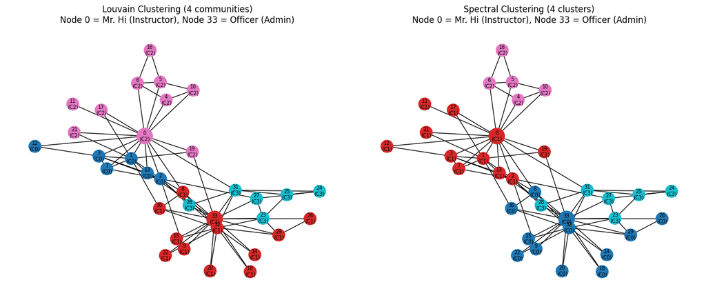

```
--- Alignment Analysis ---
Adjusted Rand Index: 0.743 (1.0 = perfect agreement, 0 = random)

--- Community Membership ---
Community 0: [1, 2, 3, 7, 12, 13]
Community 1: [8, 9, 14, 15, 18, 20, 22, 26, 29, 30, 32, 33]
Community 2: [0, 4, 5, 6, 10, 11, 16, 17, 19, 21]
Community 3: [23, 24, 25, 27, 28, 31]
```

```python
import networkx as nx
import community as community_louvain
from sklearn.cluster import SpectralClustering
import matplotlib.pyplot as plt
import numpy as np

# Create a social network graph
G = nx.karate_club_graph()

# Apply Louvain Algorithm
partition = community_louvain.best_partition(G)
num_louvain_communities = len(set(partition.values()))
print(f"Louvain detected {num_louvain_communities} communities")
print(f"Louvain partition: {partition}")

# Get adjacency matrix for spectral clustering
A = nx.to_numpy_array(G)

# Try spectral clustering with same number of clusters as Louvain found
spectral = SpectralClustering(n_clusters=num_louvain_communities, affinity='precomputed', random_state=42)
spectral_labels = spectral.fit_predict(A)
print(f"\nSpectral Clustering labels: {dict(enumerate(spectral_labels))}")

# Compare the two methods
print("\n--- Comparison ---")
print(f"Louvain communities: {num_louvain_communities}")
print(f"Spectral clusters: {num_louvain_communities} (set to match Louvain)")

# Create labels showing "node_id (community)"
louvain_node_labels = {node: f"{node}\n(C{partition[node]})" for node in G.nodes()}
spectral_node_labels = {node: f"{node}\n(C{spectral_labels[node]})" for node in G.nodes()}

# Highlight key members (Mr. Hi = 0, Officer = 33)
node_sizes = [500 if node in [0, 33] else 300 for node in G.nodes()]

# Visualize side by side
fig, (ax1, ax2) = plt.subplots(1, 2, figsize=(14, 6))
pos = nx.spring_layout(G, seed=42)

# Louvain plot
louvain_colors = [partition[node] for node in G.nodes()]
nx.draw(G, pos, ax=ax1, node_color=louvain_colors, cmap=plt.cm.tab10,
        labels=louvain_node_labels, node_size=node_sizes, font_size=7)
ax1.set_title(f'Louvain Clustering ({num_louvain_communities} communities)\nNode 0 = Mr. Hi (Instructor), Node 33 = Officer (Admin)')

# Spectral plot
nx.draw(G, pos, ax=ax2, node_color=spectral_labels, cmap=plt.cm.tab10,
        labels=spectral_node_labels, node_size=node_sizes, font_size=7)
ax2.set_title(f'Spectral Clustering ({num_louvain_communities} clusters)\nNode 0 = Mr. Hi (Instructor), Node 33 = Officer (Admin)')

plt.tight_layout()
plt.show()

# Check alignment between methods
print("\n--- Alignment Analysis ---")
from sklearn.metrics import adjusted_rand_score
louvain_labels = [partition[i] for i in range(len(G.nodes()))]
ari = adjusted_rand_score(louvain_labels, spectral_labels)
print(f"Adjusted Rand Index: {ari:.3f} (1.0 = perfect agreement, 0 = random)")

# Print community membership summary
print("\n--- Community Membership ---")
for c in range(num_louvain_communities):
    members = [n for n, comm in partition.items() if comm == c]
    print(f"Community {c}: {members}")
```

## Response

There are 4 communites detected with Louvain Clustering. Looking through available labels, it seems that C1 and C3 represent communities tied to node 33 and C2 and C0 are tied to node 0. The Karate Club graph is [famous for representing these two factions](https://doi.org/10.1086/jar.33.4.3629752). Spectral Clustering also detects 4 communities roughly faction-ed between Nodes 0 and 33. There are "boundary" nodes that differ but the clusters generally match.

Graph-based clustering has multiple advantages to K-means clustering. Firstly, K-means operates on the euclidean plane, meaning each data point needs features/ a feature vectors to plot it. Graph verticies and edges are better for relational data. With relational/graph-based data, the methods can optimize based on edge-density. Communities are groupd with many edges that point to each other. The Louvain method also intrinsically gives you the number of communities.